# Small Seedling PIRI GLMM

Kathleen Stutzman

2024-01-04

## Introduction:

This script, originally written as an R script, will be much more readable as an R Markdown. Therefore, I am translating it into a markdown file.

# Pitch Pine Small Seedling GLMM code

Libraries:

```r
# libraries -------------------
library(dplyr)
library(tidyverse)
library(ggplot2)
library(lme4)
library(lmerTest)
library(glmmTMB)
library(TMB)
library(emmeans)
library(DHARMa)
```

Set working directory

```r
knitr::opts_knit$set(root.dir = '/Users/user/Desktop/Data/Regen_RProj/')
```

Functions:

```r
# functions -------------------
```

Global variables:

```r
# global variables -------------------
```

Import small seedling data ready for analysis:

```r
source("Scripts/SS_Import.R")
```

Now looking just at PIRI:

```r
# filter for just PIRI
ss_PIRI <- ss_merge %>%
  filter(Species_Groups == "PIRI") %>%
  arrange(Treat_Type)

# now to make the explanatory variables factors
ss_PIRI$Treat_Type = factor(ss_PIRI$Treat_Type,
                              levels = unique(ss_PIRI$Treat_Type))

ss_PIRI$Region = factor(ss_PIRI$Region,
                              levels = unique(ss_PIRI$Region))

ss_PIRI$Site = factor(ss_PIRI$Site,
                              levels = unique(ss_PIRI$Site))
```

Import time since data and add it to the PIRI dataset

```r
time_since <- read_csv("CleanData/Treat_Year_Data.csv")
ss_merge1 <- merge(ss_PIRI, time_since, by = "Site")
#log transform time from treatment data
ss_merge1$l.TFT <- log(ss_merge1$Time_from_Treat)
```

Run the ‘Add_BA’ script and merge with dataset:

```r
source("Scripts/Add_BA.R")
```

```r
# merge with ss dataset -------------------
ss_merge2 <- merge(ss_merge1, prism_BA, by = "Plot_No")
```

Run ‘Ground_Data.R’ script and add it to PIRI dataset:

```r
source("Scripts/Ground_Data.R")

# merge with ss dataset -------------------
ss_alldata <- merge(ss_merge2, ground3, by = "Plot_No")

rm(ss_merge2,
   ss_merge1,
   ss_PIRI,
   time_since)
```

Below are many models investigated for the data. Many models had convergence issues using the glmer package, but trying them again using glmmTMB package, they did not have convergence issues

```r
# start with biggest model ------------------- this is only on half of the observations (those with veg and soil data)
ss.p_all <- glmmTMB(Total~Treat_Type + avgLD_l + l.BA_HA + l.BA_piri + l.Mineral + (1|Site/Plot_No) + offset(l.TFT),
                  data = ss_alldata,
                  family = poisson)
AIC(ss.p_all) #730.7

# - l.Mineral
ss.p2 <- glmmTMB(Total~Treat_Type + avgLD_l + l.BA_HA + l.BA_piri + (1|Site/Plot_No),
                  data = ss_alldata,
                  family = poisson)
AIC(ss.p2) #AIC is 712

# - l.BA_piri
############## best model/lowest AIC
ss.p3 <- glmmTMB(Total~Treat_Type + avgLD_l + l.BA_HA + (1|Site/Plot_No),
               data = ss_alldata,
               family = poisson)
AIC(ss.p3) # AIC 711.5

lrtest(ss.p2, ss.p3) # p = .2, so drop piri ba

# l.BA_piri instead of l.BA_HA
ss.p6 <- glmmTMB(Total~Treat_Type + avgLD_l + l.BA_piri + (1|Site/Plot_No),
               data = ss_alldata,
               family = poisson)
AIC(ss.p6) #AIC 714.8

# l.Mineral instead of avgLD_l
ss.p8 <- glmmTMB(Total~Treat_Type + l.BA_piri + l.Mineral + (1|Site/Plot_No),
               data = ss_alldata,
               family = poisson)
AIC(ss.p8) # AIC 718.1

ss.p9 <- glmmTMB(Total~Treat_Type + avgLD_l + l.Mineral + (1|Site/Plot_No),
               data = ss_alldata,
               family = poisson)
AIC(ss.p9) #716.5

ss.p10 <- glmmTMB(Total~Treat_Type + l.Mineral + l.BA_HA + (1|Site/Plot_No),
               data = ss_alldata,
               family = poisson)
AIC(ss.p10) #AIC 715.5


rm(ss.p_all, ss.p2, ss.p3, ss.p6, ss.p8, ss.p9)


#models that converged both with glmer and glmmTMB:
ss.p4 <- glmmTMB(Total~Treat_Type + l.Mineral + (1|Site/Plot_No),
           data = ss_alldata,
           family = poisson)
AIC(ss.p4) #AIC is 717.7, converges

ss.p5 <- glmmTMB(Total~Treat_Type + avgLD_l + (1|Site/Plot_No),
               data = ss_alldata,
               family = poisson)
AIC(ss.p5) # converged, AIC 714.6

ss.p7 <- glmmTMB(Total~Treat_Type + l.BA_piri + (1|Site/Plot_No),
               data = ss_alldata,
               family = poisson)
AIC(ss.p7) #AIC is 719.1 (glmer and glmmTMB agree on AIC values for all the above models, so that is good)
```

Best Model

```r
ss.p3 <- glmmTMB(Total~Treat_Type + avgLD_l + l.BA_HA + (1|Site/Plot_No),
               data = ss_alldata,
               family = poisson)
summary(ss.p3) #AIC is 711.5
```

```
##  Family: poisson  ( log )
## Formula:          Total ~ Treat_Type + avgLD_l + l.BA_HA + (1 | Site/Plot_No)
## Data: ss_alldata
##
##      AIC      BIC   logLik deviance df.resid
##    711.5    749.4   -346.7    693.5      489
##
## Random effects:
##
## Conditional model:
##  Groups       Name        Variance Std.Dev.
##  Plot_No:Site (Intercept) 6.5894   2.5670
##  Site         (Intercept) 0.4593   0.6777
## Number of obs: 498, groups:  Plot_No:Site, 498; Site, 47
##
## Conditional model:
##                    Estimate Std. Error z value  Pr(>|z|)
## (Intercept)         -6.4695     1.6046  -4.032 0.0000553 ***
## Treat_TypeFallRx     4.4702     1.2676   3.527  0.000421 ***
## Treat_TypeHarvest    4.6050     1.3381   3.441  0.000579 ***
## Treat_TypeMowRx      3.1987     1.2867   2.486  0.012917 *
## Treat_TypeSpringRx   3.8408     1.2765   3.009  0.002623 **
## avgLD_l             -1.3001     0.4460  -2.915  0.003554 **
## l.BA_HA              0.5608     0.2525   2.221  0.026353 *
## ---
## Signif. codes:  0 '***' 0.001 '**' 0.01 '*' 0.05 '.' 0.1 ' ' 1
```

```r
#second best model to also test/run diagnostics on

ss.p5 <- glmmTMB(Total~Treat_Type + avgLD_l + (1|Site/Plot_No),
               data = ss_alldata,
               family = poisson)
summary(ss.p5)
```

```
##  Family: poisson  ( log )
## Formula:          Total ~ Treat_Type + avgLD_l + (1 | Site/Plot_No)
## Data: ss_alldata
##
##      AIC      BIC   logLik deviance df.resid
##    714.6    748.3   -349.3    698.6      490
##
## Random effects:
##
## Conditional model:
##  Groups       Name        Variance Std.Dev.
##  Plot_No:Site (Intercept) 7.5611   2.7497
##  Site         (Intercept) 0.4684   0.6844
## Number of obs: 498, groups:  Plot_No:Site, 498; Site, 47
##
## Conditional model:
##                    Estimate Std. Error z value Pr(>|z|)
## (Intercept)         -5.1734     1.6128  -3.208  0.00134 **
## Treat_TypeFallRx     4.1105     1.3052   3.149  0.00164 **
## Treat_TypeHarvest    4.0005     1.3547   2.953  0.00315 **
## Treat_TypeMowRx      2.5609     1.3061   1.961  0.04991 *
## Treat_TypeSpringRx   3.4898     1.3133   2.657  0.00788 **
## avgLD_l             -1.0615     0.4579  -2.318  0.02045 *
## ---
## Signif. codes:  0 '***' 0.001 '**' 0.01 '*' 0.05 '.' 0.1 ' ' 1
```

To test models against one another and see if variables contribute to the model:

```r
library(lmtest)
#lrtest(model1, model2)
```

Run DHARMa package to check model fit:

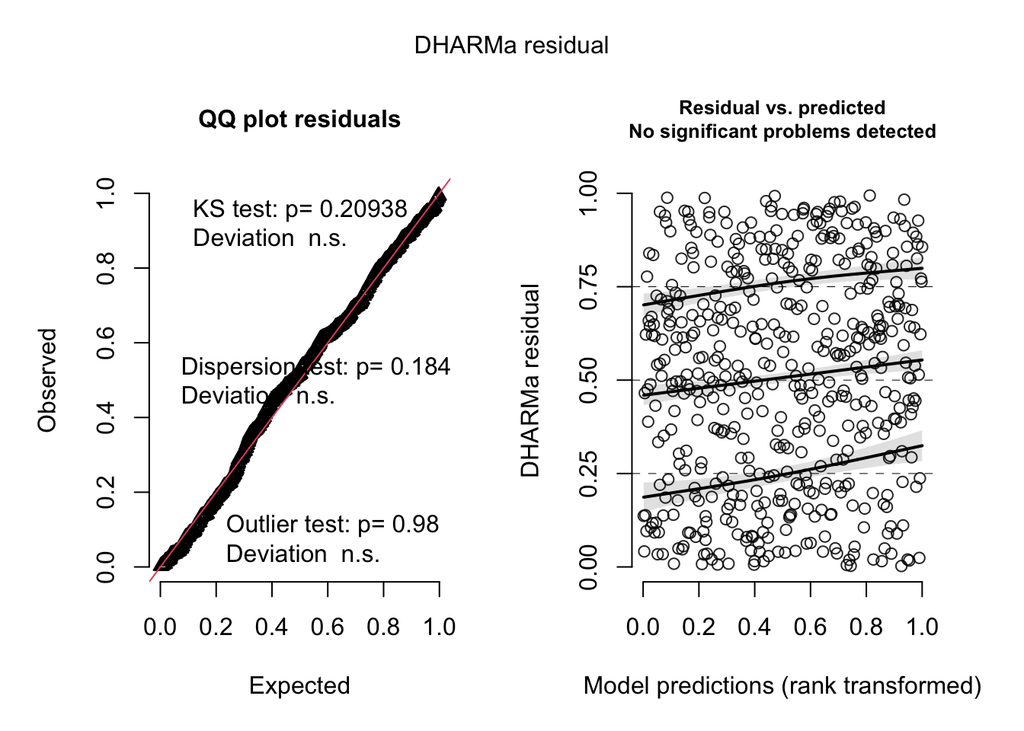

```r
ss.p3_sr <- simulateResiduals(fittedModel = ss.p3, n= 1000, plot = TRUE)
```